# Prosper_Loan_Data_Udacity

Jayashree

4 May 2017

## Prosper Loan Data

Load the csv file in to working directory

```
## [1] "C:/Users/JAYASHREE/Desktop/Data Analyst Nanodegree/EDA/Project"
```

```
##                    ListingKey     ListingNumber
##  17A93590655669644DB4C06:     6   Min.   :      4
##  349D3587495831350F0F648:     4   1st Qu.: 400919
##  47C1359638497431975670B:     4   Median : 600554
##  8474358854651984137201C:     4   Mean   : 627886
##  DE8535960513435199406CE:     4   3rd Qu.: 892634
##  04C13599434217079754AEE:     3   Max.   :1255725
##  (Other)                :113912
##                     ListingCreationDate  CreditGrade         Term
##  2013-10-02 17:20:16.550000000:     6   C      : 5649   Min.   :12.00
##  2013-08-28 20:31:41.107000000:     4   D      : 5153   1st Qu.:36.00
##  2013-09-08 09:27:44.853000000:     4   B      : 4389   Median :36.00
##  2013-12-06 05:43:13.830000000:     4   AA     : 3509   Mean   :40.83
##  2013-12-06 11:44:58.283000000:     4   HR     : 3508   3rd Qu.:36.00
##  2013-08-21 07:25:22.360000000:     3   (Other): 6745   Max.   :60.00
##  (Other)                      :113912   NA's   :84984
##                  LoanStatus                  ClosedDate
##  Current              :56576   2014-03-04 00:00:00:  105
##  Completed            :38074   2014-02-19 00:00:00:  100
##  Chargedoff           :11992   2014-02-11 00:00:00:   92
##  Defaulted            : 5018   2012-10-30 00:00:00:   81
##  Past Due (1-15 days) :  806   2013-02-26 00:00:00:   78
##  Past Due (31-60 days):  363   (Other)            :54633
##  (Other)              : 1108   NA's               :58848
##   BorrowerAPR       BorrowerRate     LenderYield
##  Min.   :0.00653   Min.   :0.0000   Min.   :-0.0100
##  1st Qu.:0.15629   1st Qu.:0.1340   1st Qu.: 0.1242
##  Median :0.20976   Median :0.1840   Median : 0.1730
##  Mean   :0.21883   Mean   :0.1928   Mean   : 0.1827
##  3rd Qu.:0.28381   3rd Qu.:0.2500   3rd Qu.: 0.2400
##  Max.   :0.51229   Max.   :0.4975   Max.   : 0.4925
##  NA's   :25
##  EstimatedEffectiveYield EstimatedLoss   EstimatedReturn
##  Min.   :-0.183          Min.   :0.005   Min.   :-0.183
##  1st Qu.: 0.116          1st Qu.:0.042   1st Qu.: 0.074
##  Median : 0.162          Median :0.072   Median : 0.092
##  Mean   : 0.169          Mean   :0.080   Mean   : 0.096
##  3rd Qu.: 0.224          3rd Qu.:0.112   3rd Qu.: 0.117
##  Max.   : 0.320          Max.   :0.366   Max.   : 0.284
##  NA's   :29084           NA's   :29084   NA's   :29084
```

[output cut: 185 more lines]

```
##  Min.   :    0.00                Min.   :0.7000   Min.   : 0.00000
##  1st Qu.:    0.00                1st Qu.:1.0000   1st Qu.: 0.00000
##  Median :    0.00                Median :1.0000   Median : 0.00000
##  Mean   :   25.14                Mean   :0.9986   Mean   : 0.04803
##  3rd Qu.:    0.00                3rd Qu.:1.0000   3rd Qu.: 0.00000
##  Max.   :21117.90                Max.   :1.0125   Max.   :39.00000
##
##  InvestmentFromFriendsCount InvestmentFromFriendsAmount   Investors
##  Min.   : 0.00000           Min.   :    0.00            Min.   :   1.00
##  1st Qu.: 0.00000           1st Qu.:    0.00            1st Qu.:   2.00
##  Median : 0.00000           Median :    0.00            Median :  44.00
##  Mean   : 0.02346           Mean   :   16.55            Mean   :  80.48
##  3rd Qu.: 0.00000           3rd Qu.:    0.00            3rd Qu.: 115.00
##  Max.   :33.00000           Max.   :25000.00            Max.   :1189.00
##
```

## Univariate Analysis

### Loan Amount

Let us analyse the loan amount taken by customers.We will plot the histogram to look at the distribution.

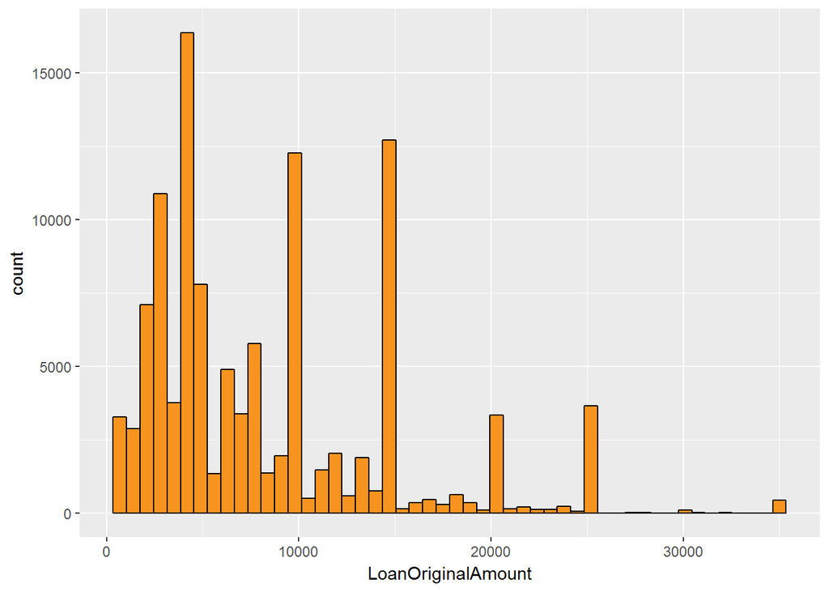

We could see from the plot that the distribution is positively skewed.Let us see the summary statistics of the loan amount.

```
##    Min. 1st Qu.  Median    Mean 3rd Qu.    Max.
##    1000    4000    6500    8337   12000   35000
```

Let us take log transformation of Loan Amount and see the distribution

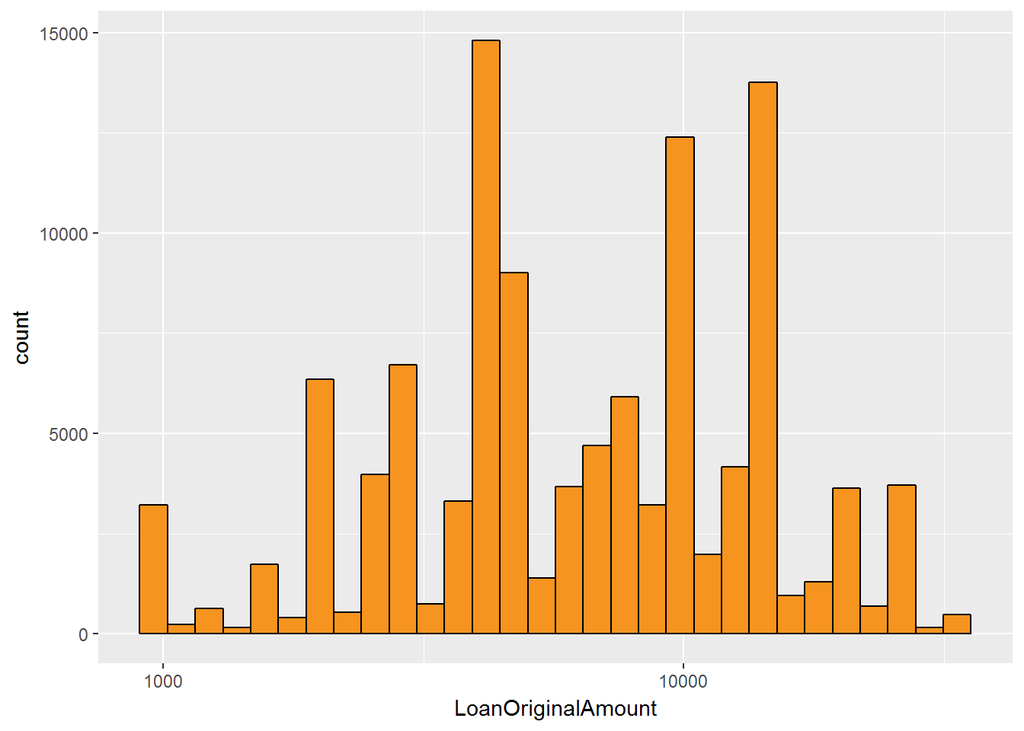

### Term

Let us take a look at the term column.We will plot a bar graph to understand the distribution of the variable.

```
## [1] 3
```

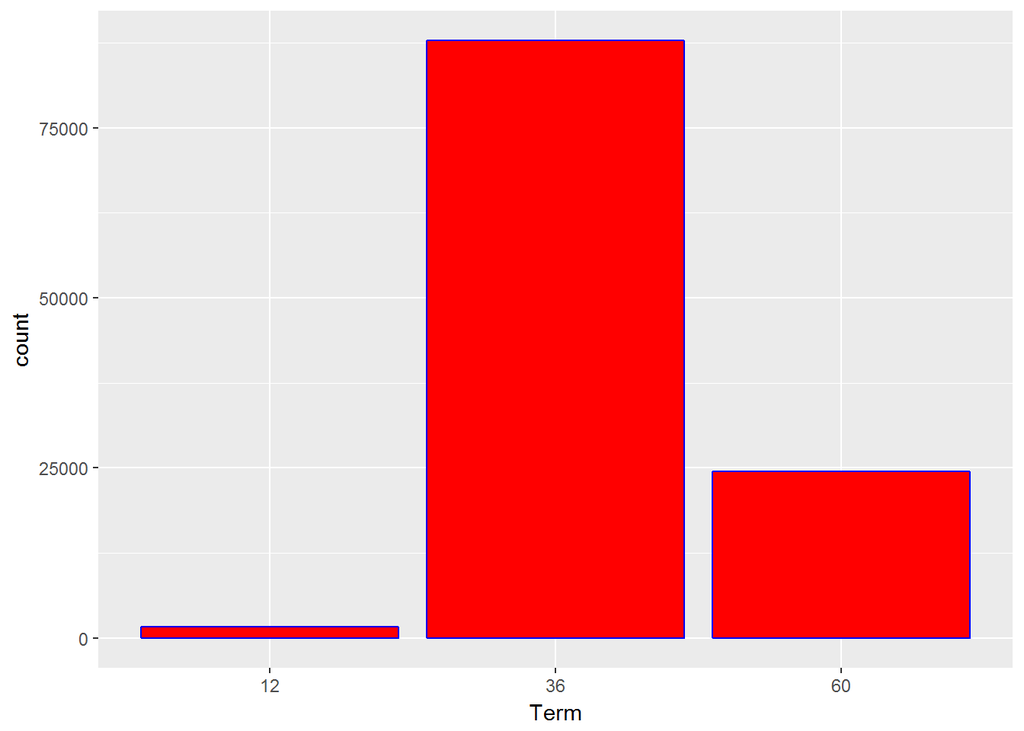

```
##
##    12    36    60
##  1614 87778 24545
```

### Income Range

Let us look at the distribution of income range of borrowers.

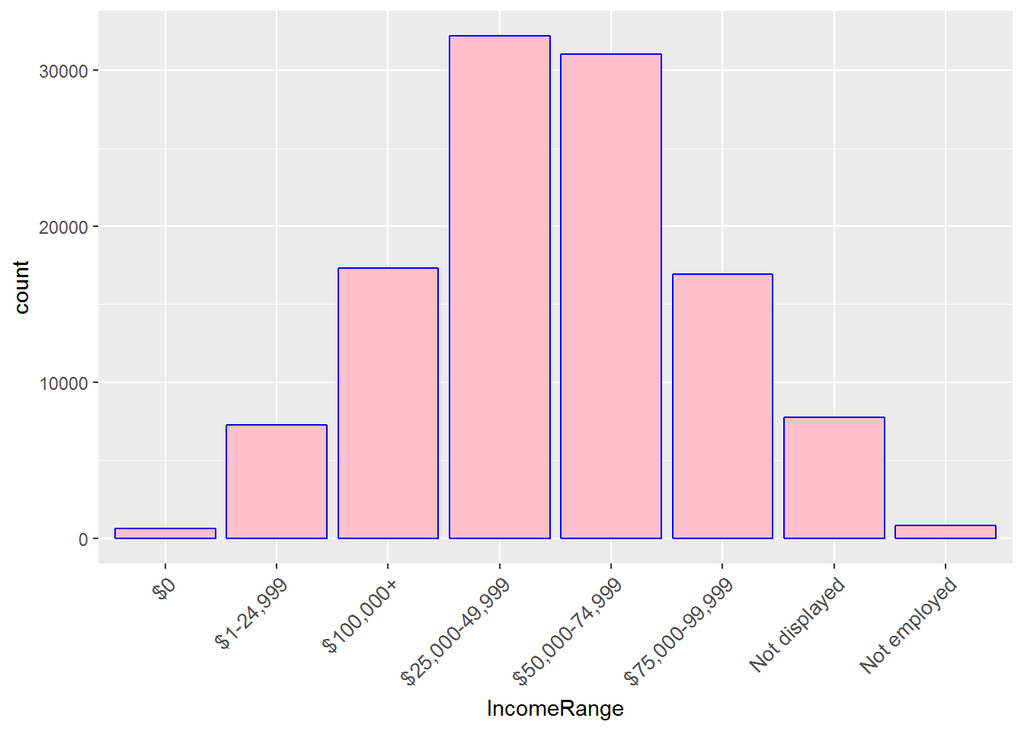

From the plot we could see that income range are not arranged in ascending order.Let us make the income range as ordered variable.

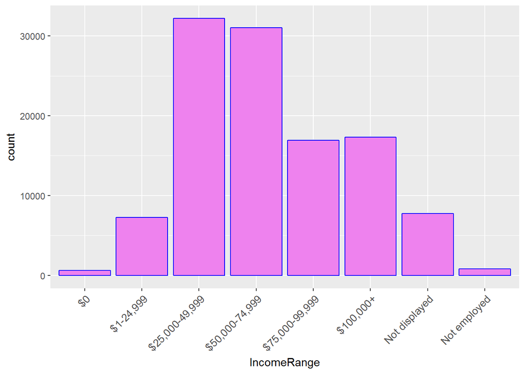

Most of the borrowers are in $25000-49999 Income range,closely followed by 50,000-74999 range.

### Listing Category

Let us find out the purpose for which the borrowers have taken a loan.

```
##
##     0     1     2     3     4     5     6     7     8     9    10    11
## 16965 58308  7433  7189  2395   756  2572 10494   199    85    91   217
##    12    13    14    15    16    17    18    19    20
##    59  1996   876  1522   304    52   885   768   771
```

We could see that for Category 1-Debt Consolidation,many borrowers have taken loan.

### Employment status

Let us look at the employment status of the borrowers.

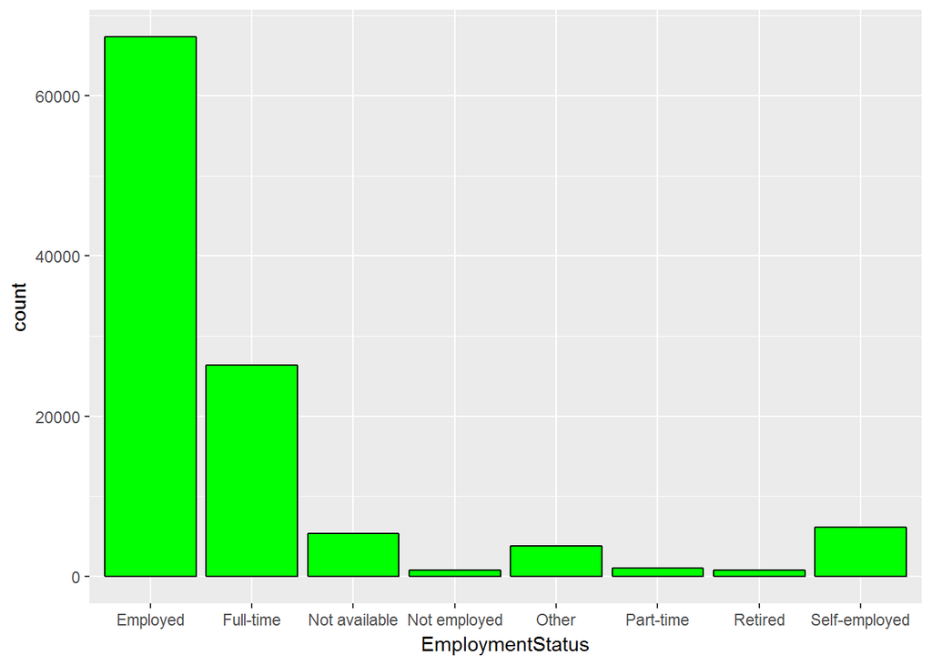

Let us take log transformation of count so that lower values are visible

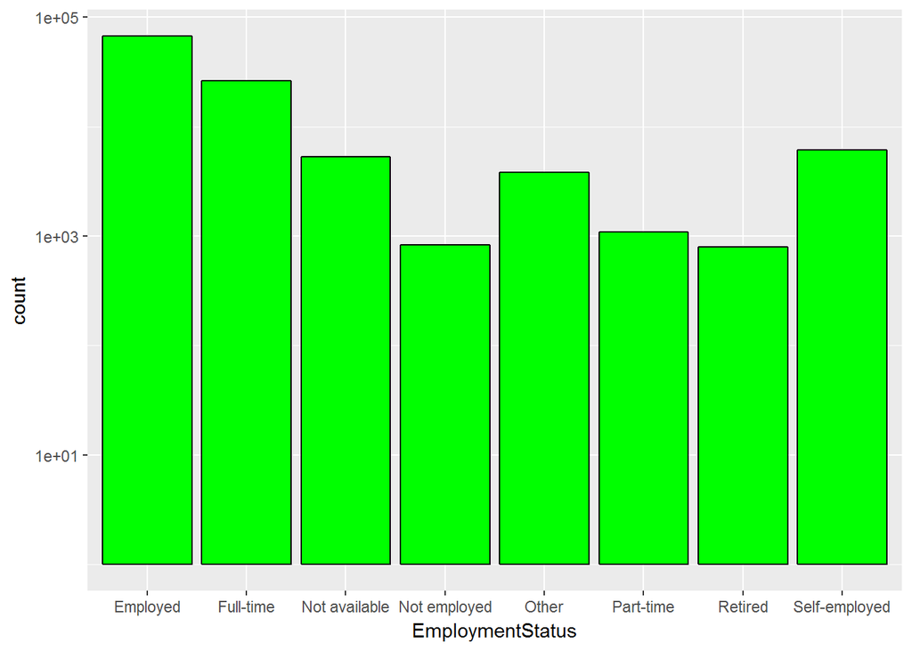

### Unique borrowers in the dataset

Let us find how many unique borrowers are in the dataset.

```
## [1] 90831
```

Let us compute the percentage of first time borrowers

```
## [1] 0.7972037
```

79.7 % of borrowers in the dataset are first time borrowers.

### LoanOriginationQuarter

Let us look at the loan origination quarter for borrowers.

Let us find out in which quarter loans have originated the most.

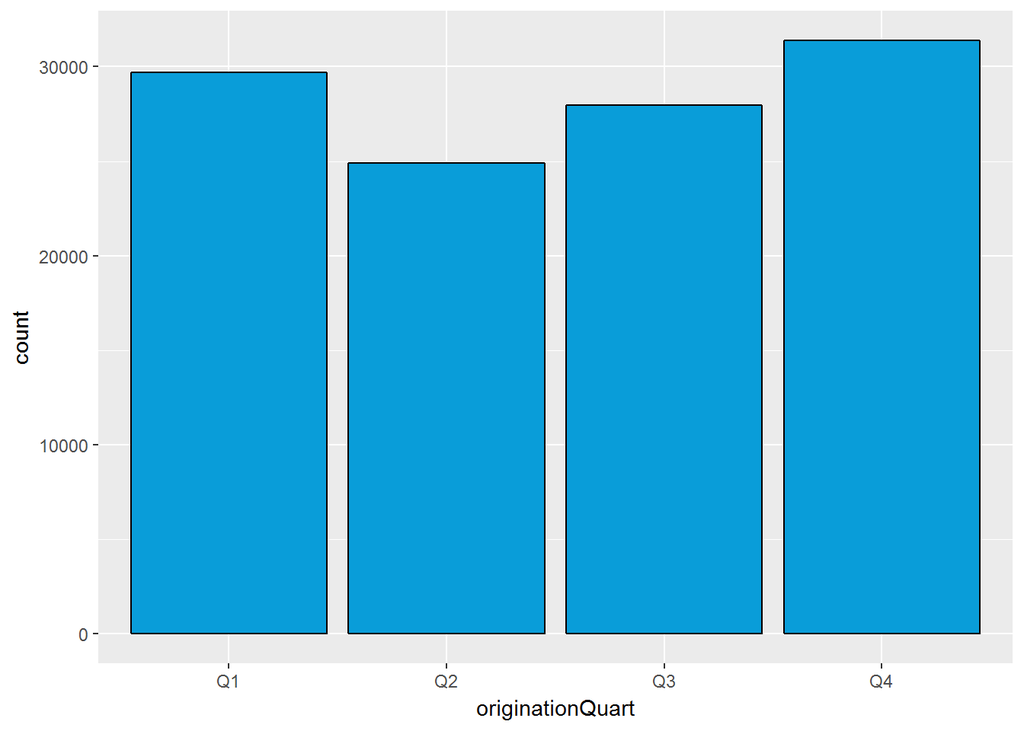

As seen from the plot most loans have originated in the 4th quarter.

### LoanOriginationDate

Let us look at the ditribution of origination of loans across days of the month.

Let us plot bar graph to find the distribution of origination of loan across days of the month.

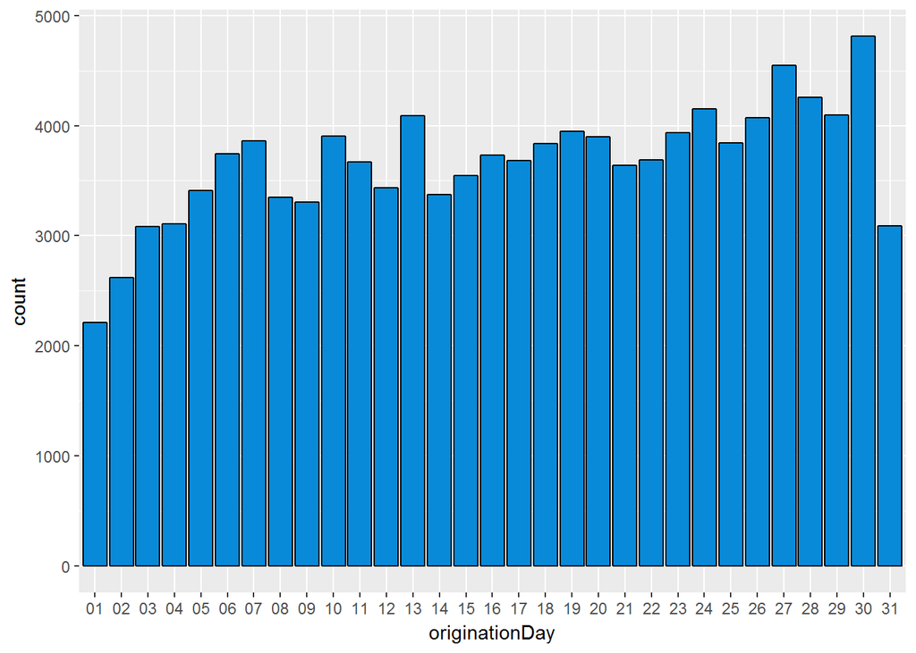

Most loans have originated in 30th of every month.

### Borrower State

Let us take a look at the distribution of states of the borowers from where they have originated.

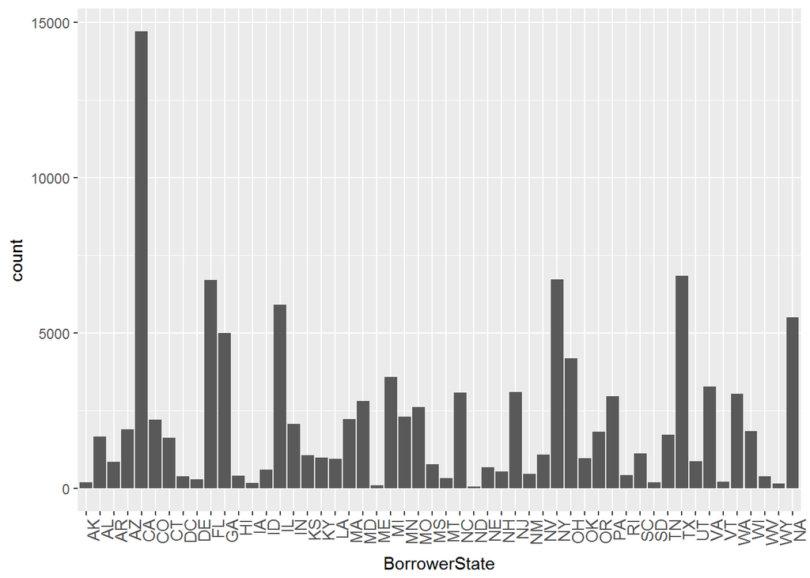

From the plot we could see that state of California has highest number of borrowers.

### CurrentlyInGroup

Let us check the proportion of borrowers who are currenty in a group.

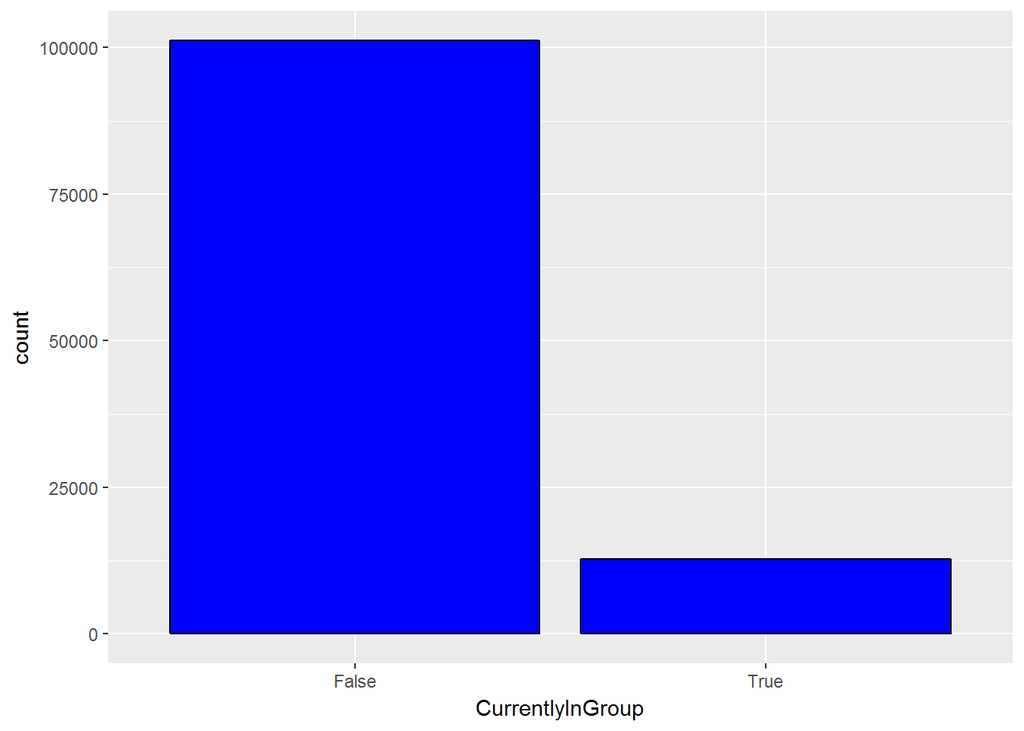

We could see from the plot that less than 1/4th of the borrowers are currently in a group.

### StatedMonthlyIncome

Let us look at the summary statistics of the monthly income

```
##    Min. 1st Qu.  Median    Mean 3rd Qu.    Max.
##       0    3200    4667    5608    6825 1750000
```

We could see a huge difference between value in 3rd quartile and maximum value. This shows the presence of outliers.

Let us look at the distribution of statedMontlyIncome of the borrowers within 3rd quartile.

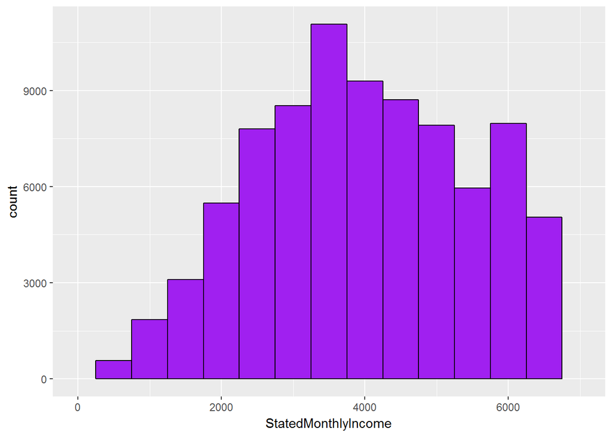

From the plot we could see that distribution is nearly normal.

### IsBorrowerHomeOwner

Let us look at the distribution of home ownership of borrowers.

```
##
## False  True
## 56459 57478
```

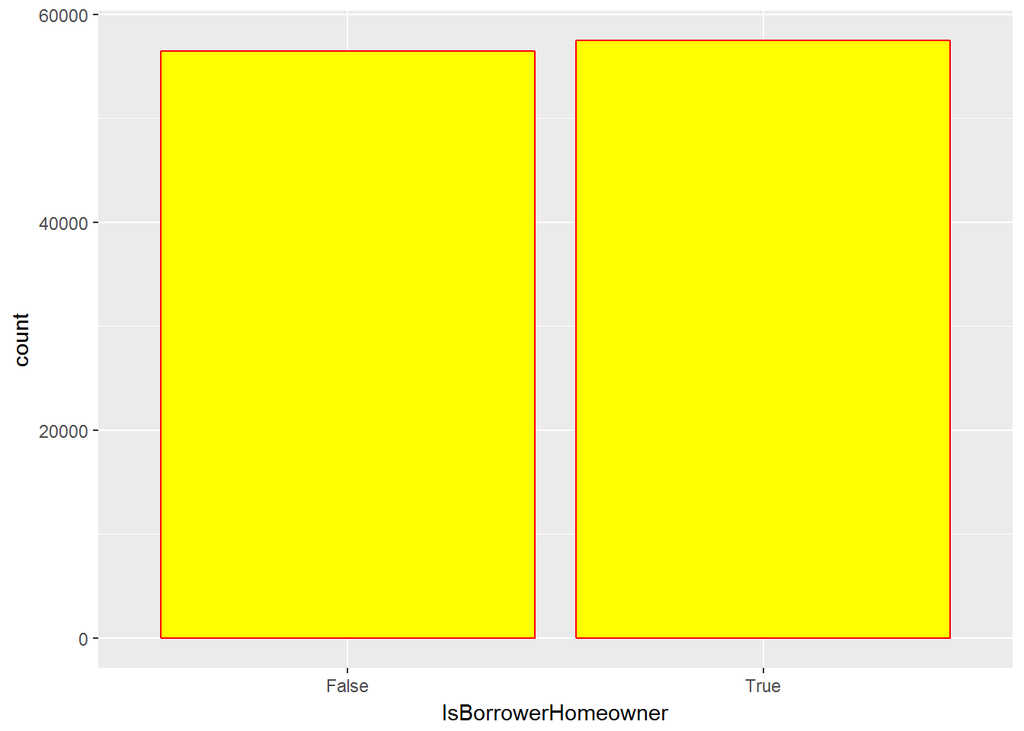

Borrowers with home ownership are slightly higher than borrowers without home ownership. ## Bi-variate Analysis

### StatedMonthlyIncome Vs LoanOriginalAmount

Let us find if monthly income of the borrower has an impact on his loan amount.

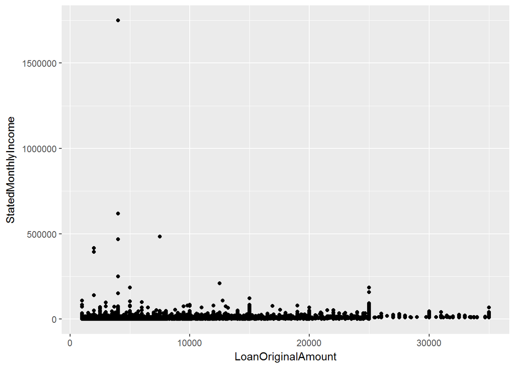

In the above figure,data points are concentrated near the x-axis,so we shall limit the y-axis values to take a closer look at the data points.

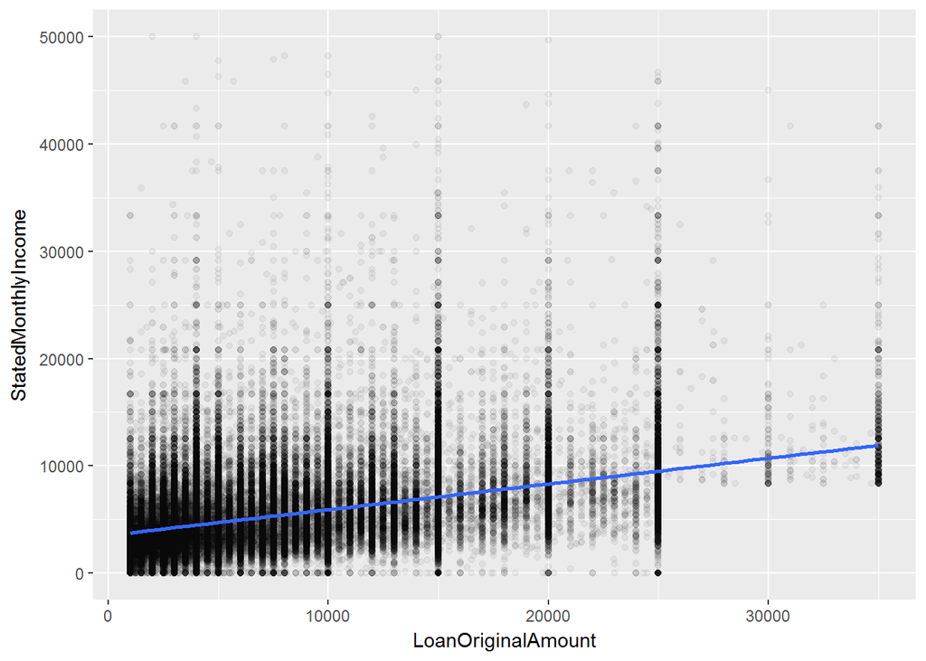

From the figure we could not find a linear relationship.Let us compute correlation coefficient and see what it tells about the strength between loan amount and monthly salary.

```
##
##  Pearson's product-moment correlation
##
## data:  LoanOriginalAmount and StatedMonthlyIncome
## t = 69.353, df = 113940, p-value < 2.2e-16
## alternative hypothesis: true correlation is not equal to 0
## 95 percent confidence interval:
##  0.1956816 0.2068243
## sample estimates:
##       cor
## 0.2012595
```

### Employment Status vs Loan Amount

I assume that Employed people are eligible for higher loan amount than other category of people.Let us plot the relation between these 2 variables to find whether my assumptions hold right.

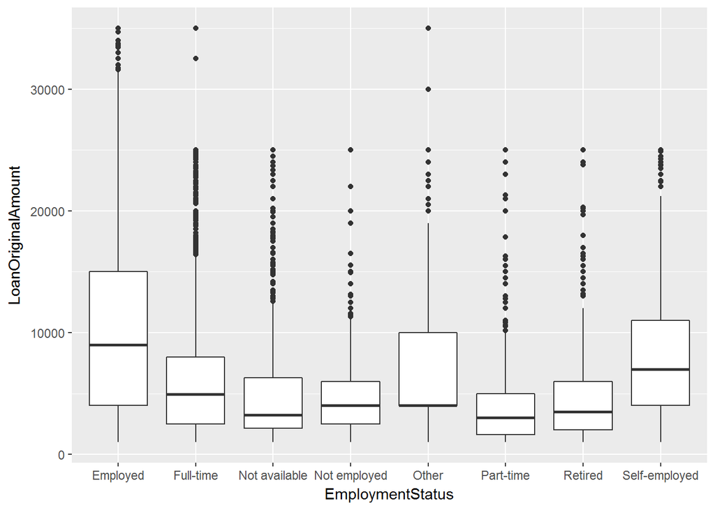

My assumptions holds true that Employed persons get higher loan amount. Let us look at the summary statistics for each employment group.

```
## loan$EmploymentStatus: Employed
##    Min. 1st Qu.  Median    Mean 3rd Qu.    Max.
##    1000    4000    9000    9794   15000   35000
## --------------------------------------------------------
## loan$EmploymentStatus: Full-time
##    Min. 1st Qu.  Median    Mean 3rd Qu.    Max.
##    1000    2500    4950    6195    8000   35000
## --------------------------------------------------------
## loan$EmploymentStatus: Not available
##    Min. 1st Qu.  Median    Mean 3rd Qu.    Max.
##    1000    2138    3225    5373    6300   25000
## --------------------------------------------------------
## loan$EmploymentStatus: Not employed
##    Min. 1st Qu.  Median    Mean 3rd Qu.    Max.
##    1000    2500    4000    4873    6000   25000
## --------------------------------------------------------
## loan$EmploymentStatus: Other
##    Min. 1st Qu.  Median    Mean 3rd Qu.    Max.
##    1000    4000    4000    6862   10000   35000
## --------------------------------------------------------
## loan$EmploymentStatus: Part-time
##    Min. 1st Qu.  Median    Mean 3rd Qu.    Max.
##    1000    1600    3000    4089    5000   25000
## --------------------------------------------------------
## loan$EmploymentStatus: Retired
##    Min. 1st Qu.  Median    Mean 3rd Qu.    Max.
##    1000    2000    3500    4784    6000   25000
## --------------------------------------------------------
## loan$EmploymentStatus: Self-employed
##    Min. 1st Qu.  Median    Mean 3rd Qu.    Max.
##    1000    4000    7000    8123   11000   25000
```

### Let us the see the proportion of borrower home owner

```
##
## False  True
## 56459 57478
```

I assume that the loan amount will be higher for the borrower with home.Let us find out if my assumption is right by plotting a frequency polygon.

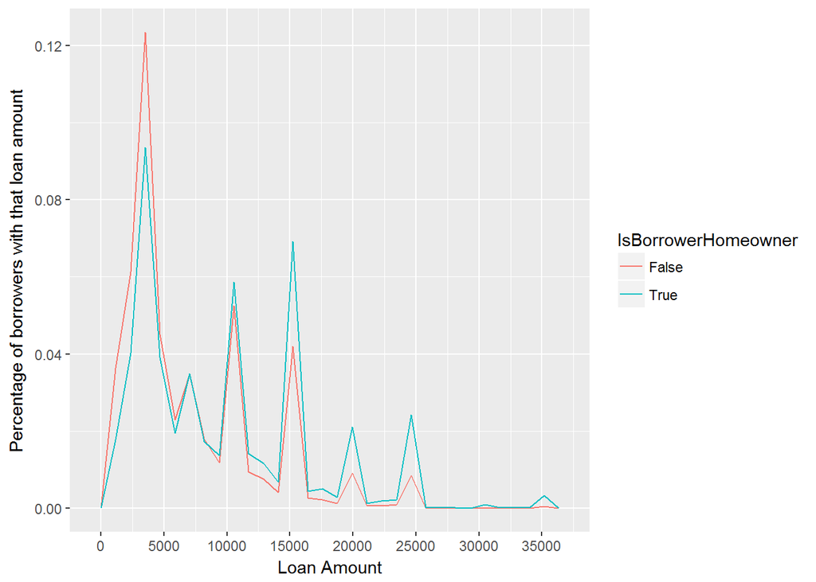

From the plot we could see that for lower amounts of loan amount the percentage of borrowers without home ownership is higher but as the loan amount increases home owner borrower has higher percentage of loan amount.

### Employment status vs Amount delinquent

Let us find the distribution of amount delinquent for various categories of employment status.

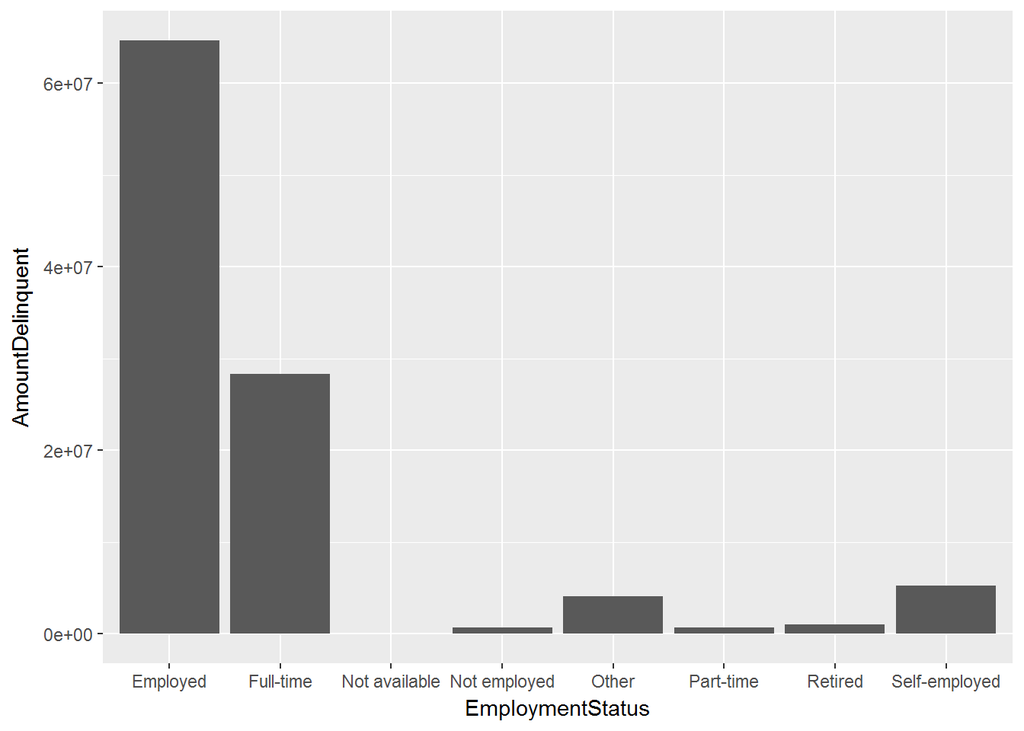

From the plot we could infer that Employed borrowers has high amount delinquent.

### Employment status Duration vs Amount Delinquent

Let us look at the relationship of amount delinquent to the number of months the borrower was employed.

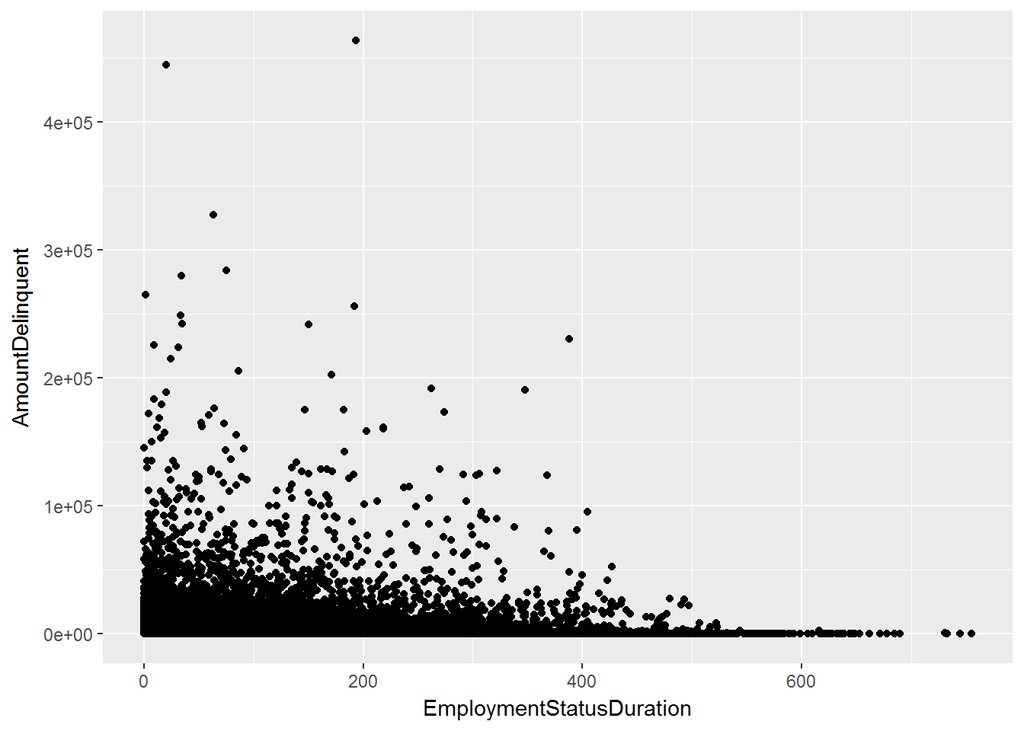

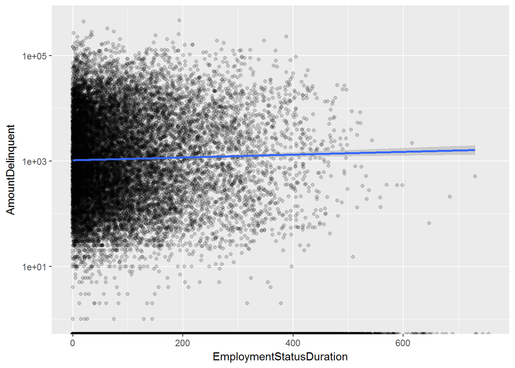

Let us find the correlation between these 2 variables

```
##
##  Pearson's product-moment correlation
##
## data:  EmploymentStatusDuration and AmountDelinquent
## t = 2.6685, df = 106290, p-value = 0.007621
## alternative hypothesis: true correlation is not equal to 0
## 95 percent confidence interval:
##  0.002173077 0.014195710
## sample estimates:
##         cor
## 0.008184689
```

We could see from the correlation coefficient that both the vairables are weakly related.

### InvestmentFromFriendsCount vs InvestmentFromFriendsAmount

I assume that as more friends chips in the amount collected will be high.Let us see if that assumption is correct.

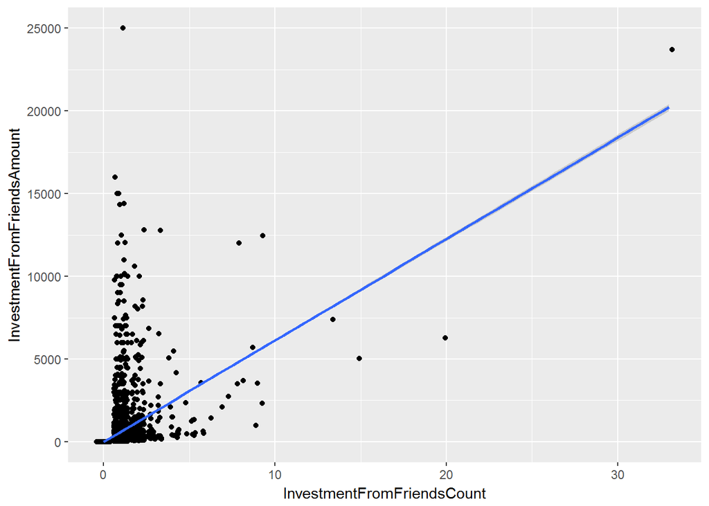

From the plot we could see that my assumption is wrong.There is no strong relationship between friends count and friends amount.

```
##
##      0      1      2      3      4      5      6      7      8      9
## 111806   1835    215     40     15      8      4      2      3      5
##     13     15     20     33
##      1      1      1      1
```

Only few borrowers have friends chiped in to lend the loan.

```
## loan$InvestmentFromFriendsCount: 0
##    Min. 1st Qu.  Median    Mean 3rd Qu.    Max.
##       0       0       0       0       0       0
## --------------------------------------------------------
## loan$InvestmentFromFriendsCount: 1
##     Min.  1st Qu.   Median     Mean  3rd Qu.     Max.
##    25.00    51.97   117.30   774.40   525.40 25000.00
## --------------------------------------------------------
## loan$InvestmentFromFriendsCount: 2
##    Min. 1st Qu.  Median    Mean 3rd Qu.    Max.
##    55.0   168.5   431.9  1285.0  1195.0 12800.0
## --------------------------------------------------------
## loan$InvestmentFromFriendsCount: 3
##    Min. 1st Qu.  Median    Mean 3rd Qu.    Max.
##   150.0   257.5   518.3  1457.0  1500.0 12780.0
## --------------------------------------------------------
## loan$InvestmentFromFriendsCount: 4
##    Min. 1st Qu.  Median    Mean 3rd Qu.    Max.
##   250.0   431.9   734.8  1640.0  1800.0  5477.0
## --------------------------------------------------------
## loan$InvestmentFromFriendsCount: 5
##    Min. 1st Qu.  Median    Mean 3rd Qu.    Max.
##   385.0   469.5   887.9  1012.0  1316.0  2350.0
## --------------------------------------------------------
## loan$InvestmentFromFriendsCount: 6
##    Min. 1st Qu.  Median    Mean 3rd Qu.    Max.
##   500.0   593.8  1028.0  1526.0  1960.0  3550.0
## --------------------------------------------------------
## loan$InvestmentFromFriendsCount: 7
##    Min. 1st Qu.  Median    Mean 3rd Qu.    Max.
##    2110    2270    2430    2430    2590    2750
## --------------------------------------------------------
## loan$InvestmentFromFriendsCount: 8
##    Min. 1st Qu.  Median    Mean 3rd Qu.    Max.
##    3505    3594    3683    6403    7852   12020
## --------------------------------------------------------
## loan$InvestmentFromFriendsCount: 9
##    Min. 1st Qu.  Median    Mean 3rd Qu.    Max.
##   988.1  2338.0  3525.0  5005.0  5712.0 12460.0
## --------------------------------------------------------
## loan$InvestmentFromFriendsCount: 13
##    Min. 1st Qu.  Median    Mean 3rd Qu.    Max.
##    7388    7388    7388    7388    7388    7388
## --------------------------------------------------------
## loan$InvestmentFromFriendsCount: 15
##    Min. 1st Qu.  Median    Mean 3rd Qu.    Max.
##    5025    5025    5025    5025    5025    5025
## --------------------------------------------------------
## loan$InvestmentFromFriendsCount: 20
##    Min. 1st Qu.  Median    Mean 3rd Qu.    Max.
##    6261    6261    6261    6261    6261    6261
## --------------------------------------------------------
## loan$InvestmentFromFriendsCount: 33
##    Min. 1st Qu.  Median    Mean 3rd Qu.    Max.
##   23700   23700   23700   23700   23700   23700
```

### Employment status vs Investors

Let us look at the distribution of investors who have lended the loan.

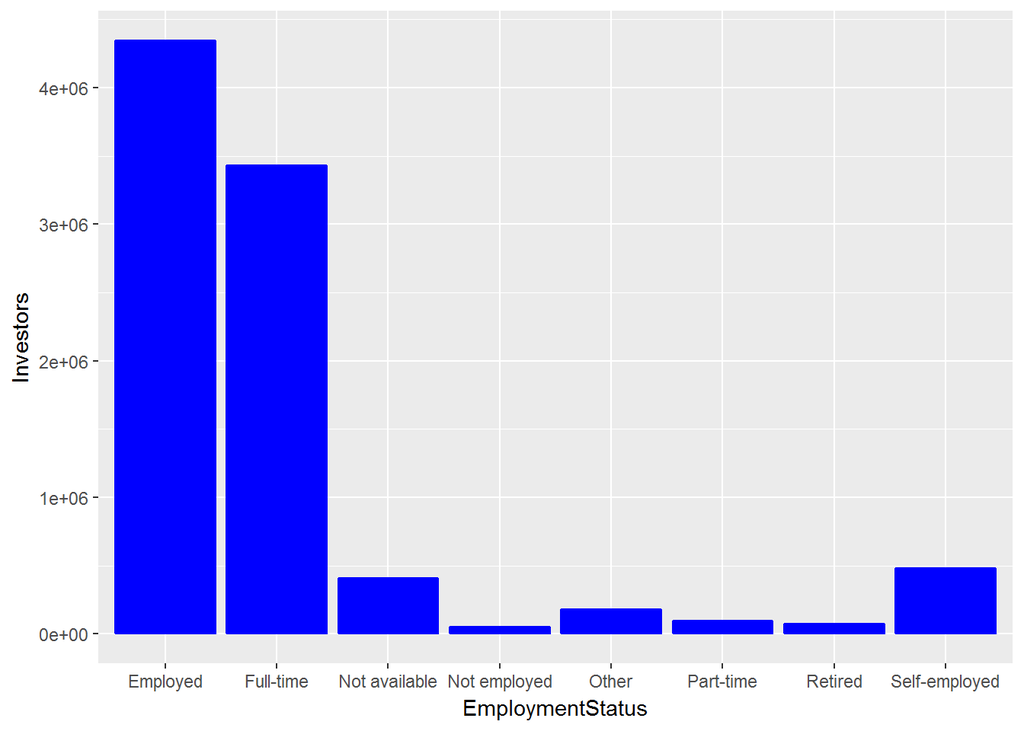

As seen from the plot investors are funding high for employed borrowers.

## Multivariate Analysis

### Monthly Income vs Loan Amount based on Employment Status

Let us look at plot of monthly income vs loan amount sanctioned for each category of employed persons.

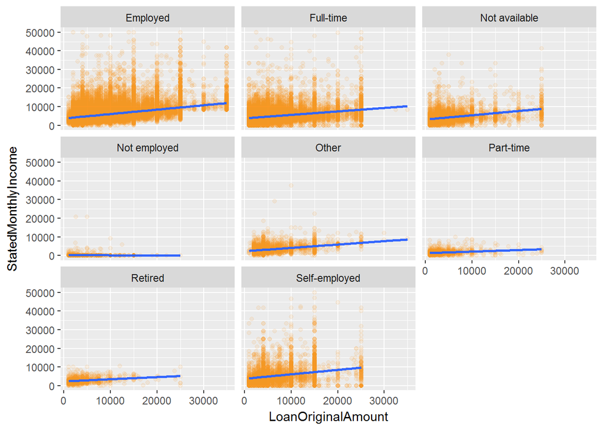

### CurrentDelinquencies vs loan amount for various categories of

### Employmentstatus

Let us calculate median loan amount for borrowers who have current delinquencies for varied category of employment status.

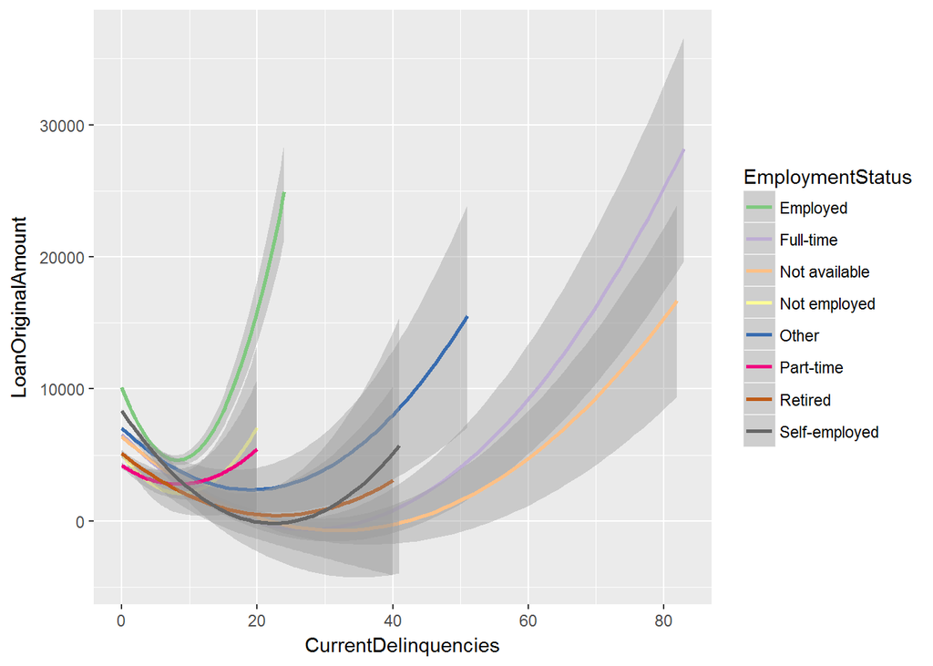

### Borrowers APR vs Borrower Rate based on Term

Let us find if term of loan impact the interest rate and Annual Percentage Rate

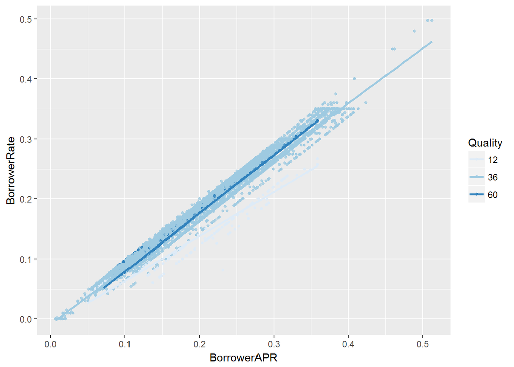

As term increases,borrower APR increases with borrower interest rate forming a linear relationship.Let us look at the correlation coefficient.

```
##
##  Pearson's product-moment correlation
##
## data:  BorrowerAPR and BorrowerRate
## t = 2347.7, df = 113910, p-value < 2.2e-16
## alternative hypothesis: true correlation is not equal to 0
## 95 percent confidence interval:
##  0.9897057 0.9899409
## sample estimates:
##      cor
## 0.989824
```

This shows that both the variables have strong linear relationship.

### Income Range vs Stated Monthly Income based on Income verifiable

Let us look at the distribution of montly income of borrowers based on their income range and verificaton of income.

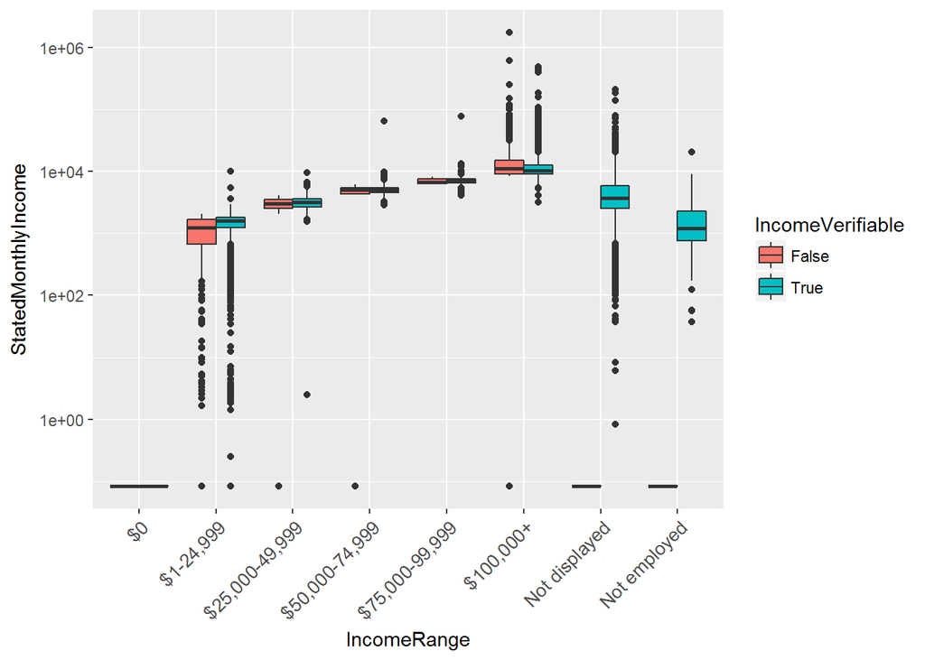

The plot shows that only few borrowers have given information about verification of income.

## Final Plots and Summaries

### Plot One

#### Employment Status vs Loan Original Amount

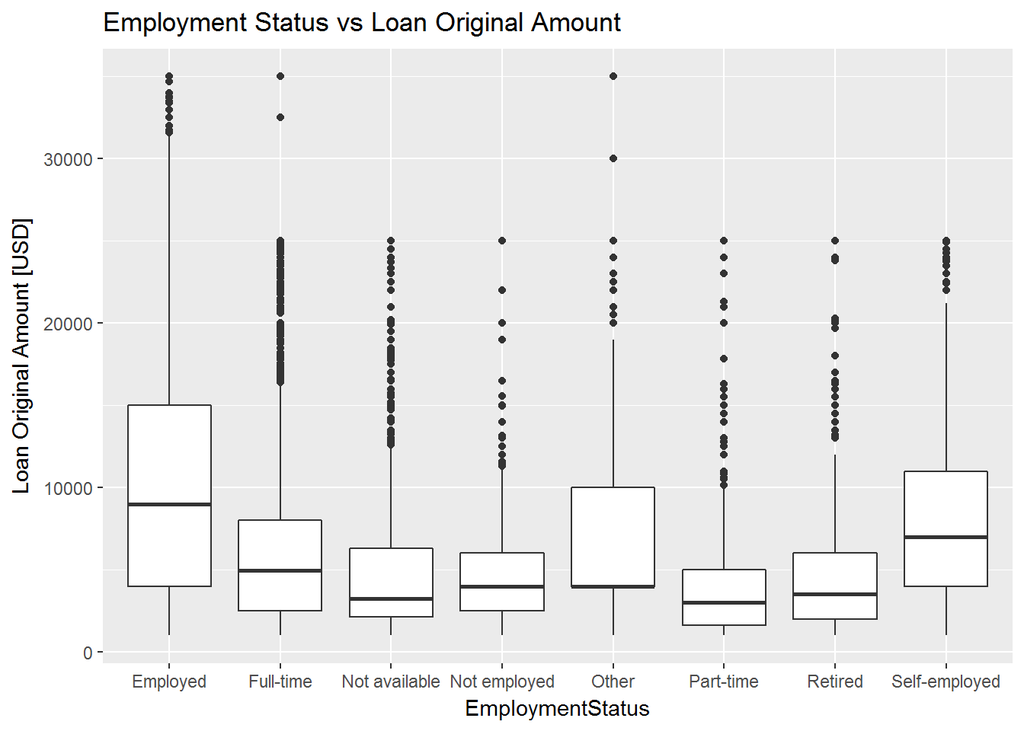

The boxplot shows that the median loan amount for employed borrowers are higher. Also lots of outliers are present for full-time and not available category of borrowers.Let us look at the summary statistics for the plot.

```
## loan$EmploymentStatus: Employed
##    Min. 1st Qu.  Median    Mean 3rd Qu.    Max.
##    1000    4000    9000    9794   15000   35000
## --------------------------------------------------------
## loan$EmploymentStatus: Full-time
##    Min. 1st Qu.  Median    Mean 3rd Qu.    Max.
##    1000    2500    4950    6195    8000   35000
## --------------------------------------------------------
## loan$EmploymentStatus: Not available
##    Min. 1st Qu.  Median    Mean 3rd Qu.    Max.
##    1000    2138    3225    5373    6300   25000
## --------------------------------------------------------
## loan$EmploymentStatus: Not employed
##    Min. 1st Qu.  Median    Mean 3rd Qu.    Max.
##    1000    2500    4000    4873    6000   25000
## --------------------------------------------------------
## loan$EmploymentStatus: Other
##    Min. 1st Qu.  Median    Mean 3rd Qu.    Max.
##    1000    4000    4000    6862   10000   35000
## --------------------------------------------------------
## loan$EmploymentStatus: Part-time
##    Min. 1st Qu.  Median    Mean 3rd Qu.    Max.
##    1000    1600    3000    4089    5000   25000
## --------------------------------------------------------
## loan$EmploymentStatus: Retired
##    Min. 1st Qu.  Median    Mean 3rd Qu.    Max.
##    1000    2000    3500    4784    6000   25000
## --------------------------------------------------------
## loan$EmploymentStatus: Self-employed
##    Min. 1st Qu.  Median    Mean 3rd Qu.    Max.
##    1000    4000    7000    8123   11000   25000
```

I have chose this plot as this shows clear trend.

### Plot Two

#### Percentage of home owners vs Loan Original Amount

For lower amounts of loan home ownership is not a major influencing factor.But for higher loan amount,home ownership becomes an important factor.This may be due to the reason that house document can be mortaged incase of failure to repay the loan.

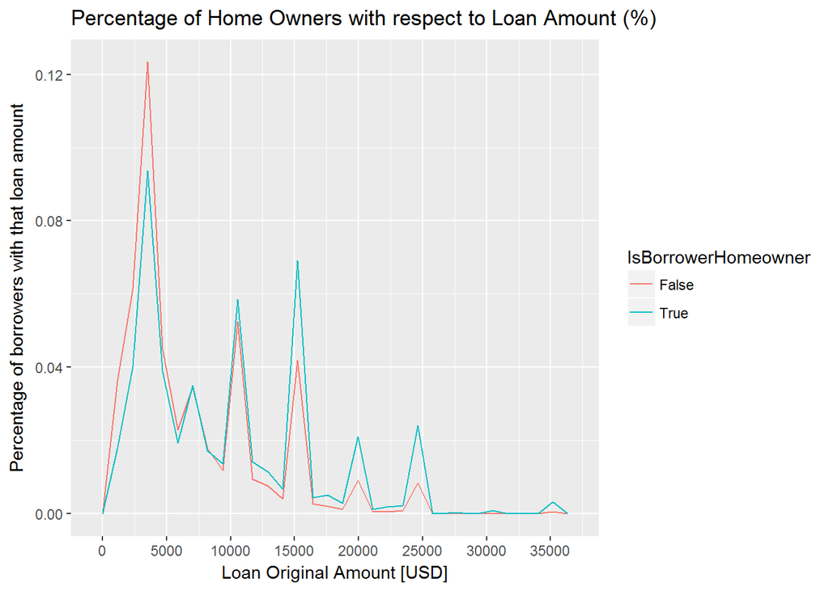

Let us look at the proportion of home owners in the dataset.

```
##
## False  True
## 56459 57478
```

### Plot Three

#### Borrowers APR vs Borrower Rate based on Term

As term increases there is a linear relationship between Borrower APR and Borrower Rate.

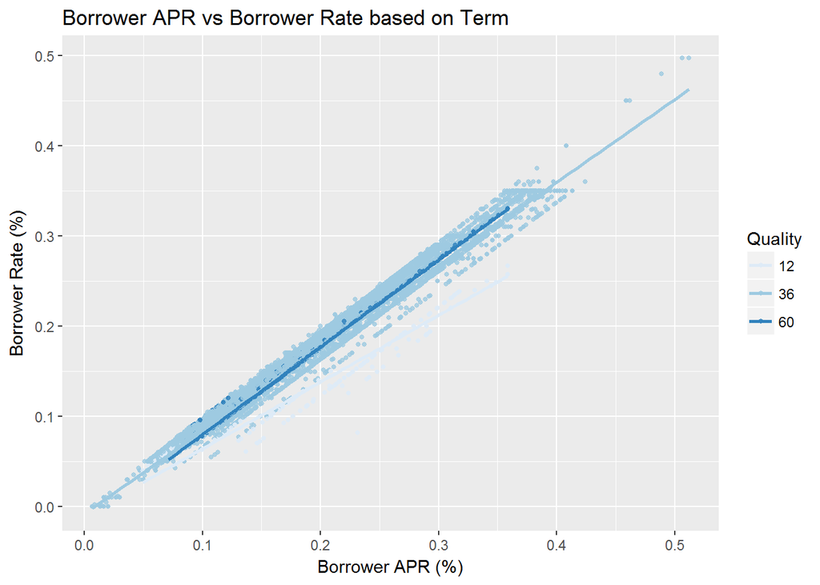

Let us calculate correlation coefficient to check for linearity.

```
##
##  Pearson's product-moment correlation
##
## data:  BorrowerAPR and BorrowerRate
## t = 2347.7, df = 113910, p-value < 2.2e-16
## alternative hypothesis: true correlation is not equal to 0
## 95 percent confidence interval:
##  0.9897057 0.9899409
## sample estimates:
##      cor
## 0.989824
```

The values shows that both the variables have strong linear relationship.

## Reflection

Prosper Loan dataset is a huge dataset of more tha 1 lakh data.As I explored the data,I found success in finding pattern of loan amount based on employment status and home ownership.I found difficult to choose the variables to explore as there are 81 of them containing varied and vast information.I have analysed around 20 variables.There is a lot of scope in taking this project forward. All the variables can be analysed and plotted to check for the trend and model can be built.